# RStudio Exercise 6

We can further study the differences and similarities between groups by looking at the standardized data

```
## Observations: 176
## Variables: 5
## $ ID        <fct> 1, 2, 3, 4, 5, 6, 7, 8, 9, 10, 11, 12, 13, 14, 15, 1...
## $ Group     <fct> 1, 1, 1, 1, 1, 1, 1, 1, 2, 2, 2, 2, 3, 3, 3, 3, 1, 1...
## $ Time      <dbl> 1, 1, 1, 1, 1, 1, 1, 1, 1, 1, 1, 1, 1, 1, 1, 1, 8, 8...
## $ Weight    <int> 240, 225, 245, 260, 255, 260, 275, 245, 410, 405, 44...
## $ stdWeight <dbl> -1.0011429, -1.1203857, -0.9613953, -0.8421525, -0.8...
```

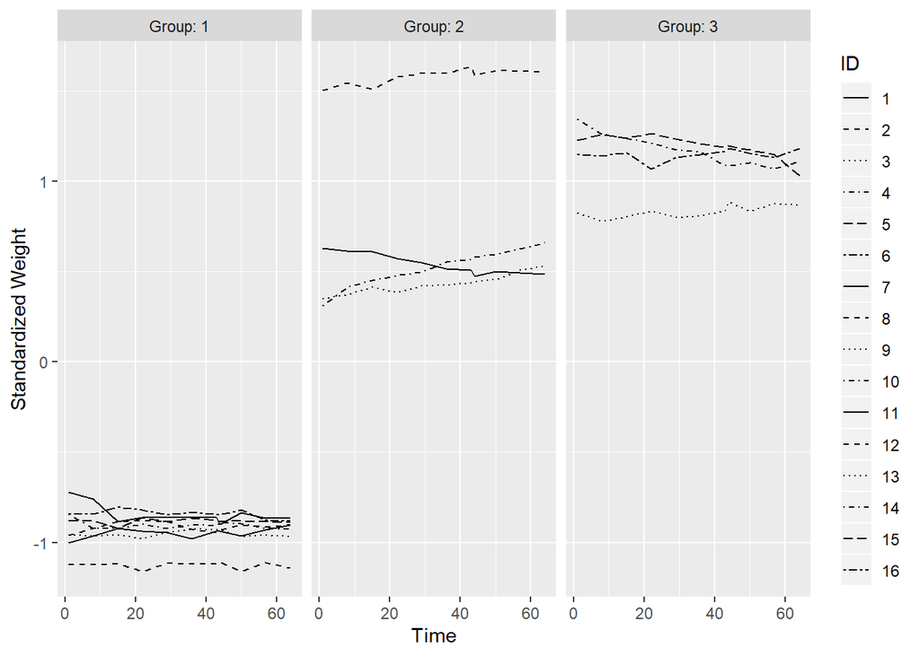

The above figure plots the standardized data for each group. We can see similar features in the above figure as in the non-standardized data, although differences between rates of changes between different groups is now less prononunced.

```
## Observations: 33
## Variables: 4
## $ Group <fct> 1, 1, 1, 1, 1, 1, 1, 1, 1, 1, 1, 2, 2, 2, 2, 2, 2, 2, 2,...
## $ Time  <dbl> 1, 8, 15, 22, 29, 36, 43, 44, 50, 57, 64, 1, 8, 15, 22, ...
## $ mean  <dbl> 250.625, 255.000, 254.375, 261.875, 264.625, 265.000, 26...
## $ se    <dbl> 4.589478, 3.947710, 3.460116, 4.100800, 3.333956, 3.5529...
```

```
##  Group       Time            mean             se
##  1:11   Min.   : 1.00   Min.   :250.6   Min.   : 3.074
##  2:11   1st Qu.:15.00   1st Qu.:269.5   1st Qu.: 4.101
##  3:11   Median :36.00   Median :486.5   Median : 7.358
##         Mean   :33.55   Mean   :424.7   Mean   :10.703
##         3rd Qu.:50.00   3rd Qu.:518.2   3rd Qu.:21.047
##         Max.   :64.00   Max.   :550.2   Max.   :22.390
```

Now, we have the standard error and the mean of each group included in the dataset, which we can plot:

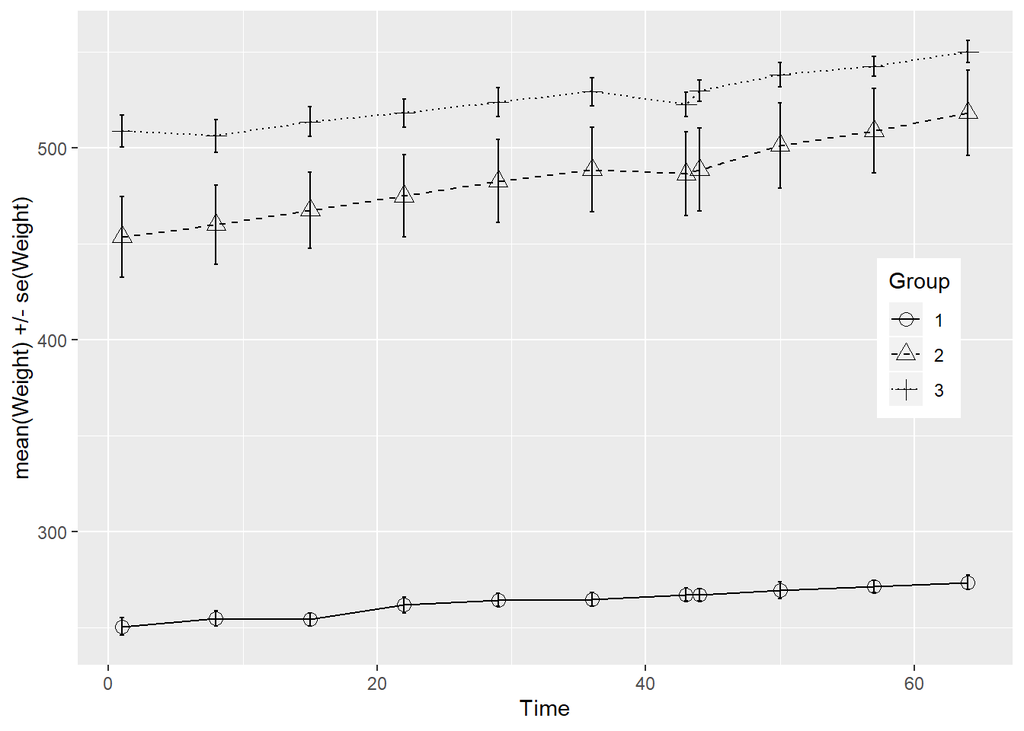

The above figure suggests that there are quite large differences between the means of each group as well as the standard errors.

We can also draw a box-plot for each time period:

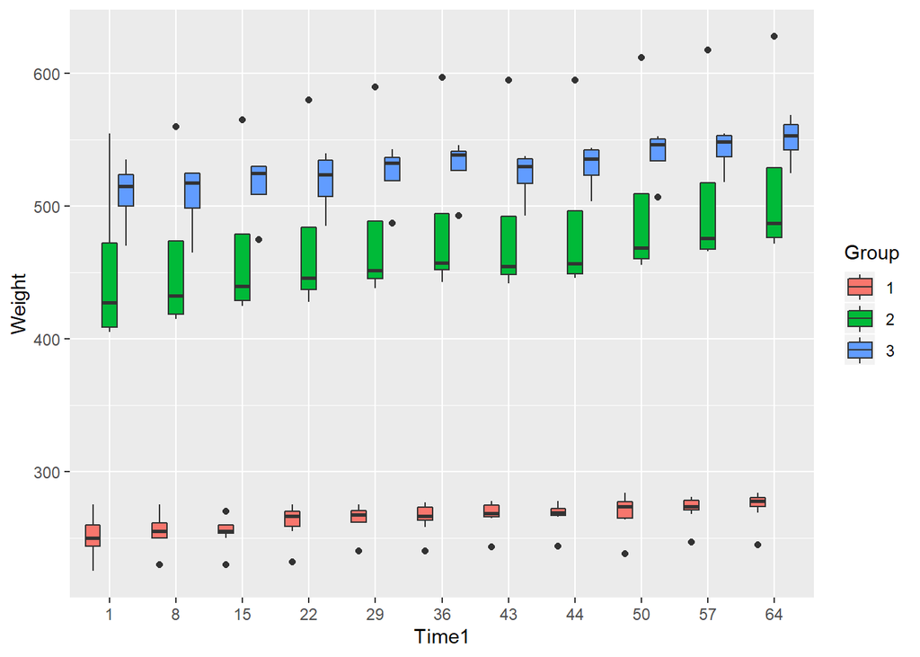

The plots suggests that there are some outliers in Group 2.

### Summary graphs

The summary measure method transforms measurements for each subject into a single measure thatcaptures essential feature of the individual in the sample. In this case, the the summary measure approach is applied to observiations by measuring the average weight after the first day of the trial until the end of the sample. Given that the data is measured at unequal intervals and that we are interested in learning about differences in the growth rate of each group, a regression coefficient would probably be a better measure, but we proceed as instructed.

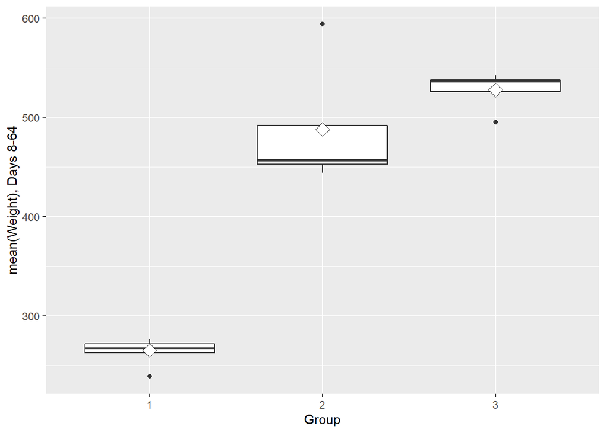

The above figure shows that the mean weight of Group 2 is more variable and skewed to the right than for other groups. We can also see that there is an outlier in Group 2, which possibly biases the results.

Next we draw a new boxplot that eliminates the outlier in Group 2.

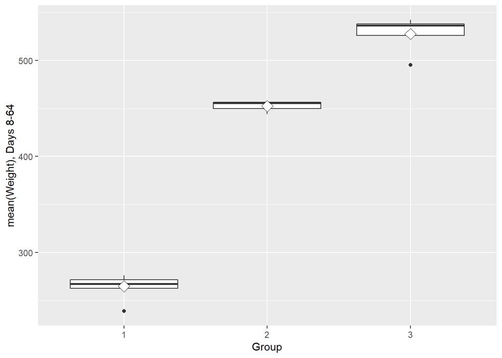

The figure confirms that there are significant differences between the means of the groups, but we must confirm this with a statistical test.

### Means testing

We cannot use a t-test two test more than two samples, so ANOVA (Analysis of Variance) is used test a hypothesis when dealing with two or more groups. One-way ANOVA can be considered an extension of the t-test when at least three groups are tested.

```
## Analysis of Variance Table
##
## Response: mean
##           Df Sum Sq Mean Sq   F value   Pr(>F)
## baseline   1 253625  253625 1859.8201 1.57e-14 ***
## Group      2    879     439    3.2219  0.07586 .
## Residuals 12   1636     136
## ---
## Signif. codes:  0 '***' 0.001 '**' 0.01 '*' 0.05 '.' 0.1 ' ' 1
```

We can see that the p-value for `Group` is less than 0.1, which means that there are differences between the different groups at the 10% confidence level.

## Analysis of longitudinal data: Part II

In this section, we use linear mixed effects models for normal response models to study the effect of two different treatments on schizophrenia. Linear mixed effects models for repeated measures data take in to account that subject’s responses depend on observed and unobserved individual characteristics. The unobserved variables are included in the model as random effects.

In the `BPRS` data subjects were randomly assigned to one of two treatment groups. Before the treatment, each subject was rated on the brief psychiatric rating scale (BPRS) and then during each of the following eight weeks. The BPRS scale is used to evaluate the presence of schizophrenia.

First we load the longitudinal data

```r
BPRSL <- read.table("data/BPRSL.txt", header=TRUE)
```

and check the structure:

```r
str(BPRSL)
```

```
## 'data.frame':    360 obs. of  4 variables:
##  $ subject  : int  1 2 3 4 5 6 7 8 9 10 ...
##  $ treatment: int  1 1 1 1 1 1 1 1 1 1 ...
##  $ Week     : int  0 0 0 0 0 0 0 0 0 0 ...
##  $ bprs     : int  42 58 54 55 72 48 71 30 41 57 ...
```

We need to change categorical values to factors in BPRSL data

```r
BPRSL$treatment <- as.factor(BPRSL$treatment)
BPRSL$subject <- as.factor(BPRSL$subject)
BPRSL$Week <- as.numeric(BPRSL$Week)
BPRSL$bprs <- as.numeric(BPRSL$bprs)
```

We can look at the differences between Wide form data and long form data. The original wide form data defines a variable for each observation period

```
##   treatment subject week0 week1 week2 week3 week4 week5 week6 week7 week8
## 1         1       1    42    36    36    43    41    40    38    47    51
## 2         1       2    58    68    61    55    43    34    28    28    28
```

However, the long form data defines variables for time and the observations, as can be seen in the table below.

```
##    subject treatment Week bprs
## 1        1         1    0   42
## 2        1         1    1   36
## 3        1         1    2   36
## 4        1         1    3   43
## 5        1         1    4   41
## 6        1         1    5   40
## 7        1         1    6   38
## 8        1         1    7   47
## 9        1         1    8   51
## 10       2         1    0   58
## 11       2         1    1   68
## 12       2         1    2   61
## 13       2         1    3   55
## 14       2         1    4   43
## 15       2         1    5   34
## 16       2         1    6   28
## 17       2         1    7   28
## 18       2         1    8   28
```

In the plot below, we ignore the repeated-measure nature of the data by abstracting from individuals and only plotting the data by treatment.

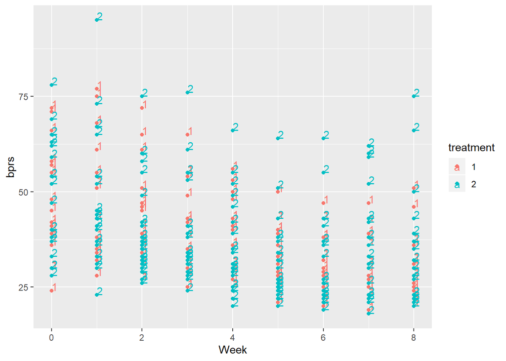

We can see that there are no clear differences between the two groups. The bprs measures seem to be decreasing over time in both groups.

If we look at the each subject separately, we can see that individual observations are correlated for each individual, suggesting the presence of random effects.

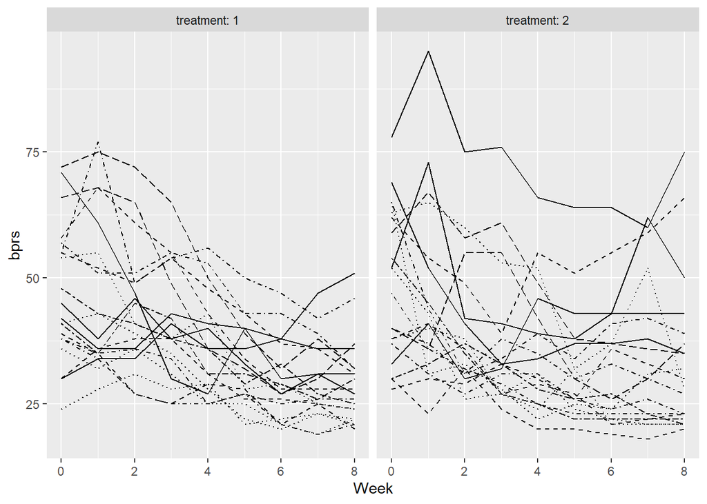

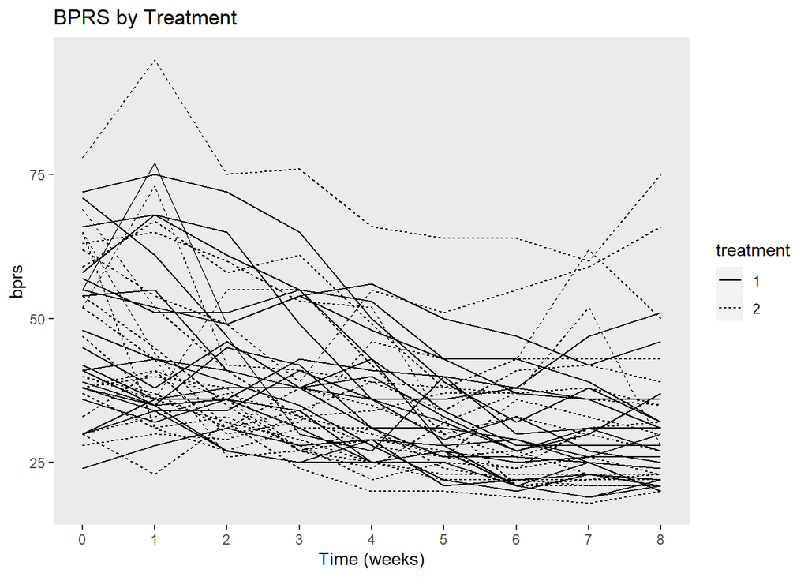

The scatterplot confirms this observation, given that observations for consecutive weeks appear to be strongly correlated.

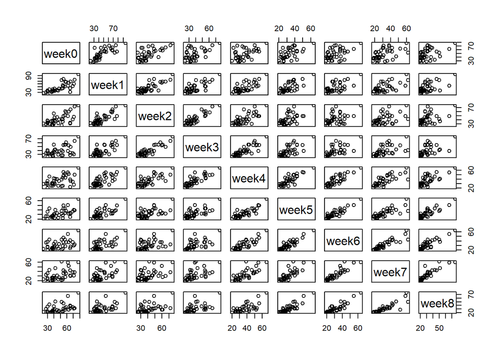

### Fitting Linear Mixed Models to `BRPS` data

#### Independence model

```
##
## Call:
## lm(formula = bprs ~ Week + treatment, data = BPRSL)
##
## Residuals:
##     Min      1Q  Median      3Q     Max
## -22.454  -8.965  -3.196   7.002  50.244
##
## Coefficients:
##             Estimate Std. Error t value Pr(>|t|)
## (Intercept)  46.4539     1.3670  33.982   <2e-16 ***
## Week         -2.2704     0.2524  -8.995   <2e-16 ***
## treatment2    0.5722     1.3034   0.439    0.661
## ---
## Signif. codes:  0 '***' 0.001 '**' 0.01 '*' 0.05 '.' 0.1 ' ' 1
##
## Residual standard error: 12.37 on 357 degrees of freedom
## Multiple R-squared:  0.1851, Adjusted R-squared:  0.1806
## F-statistic: 40.55 on 2 and 357 DF,  p-value: < 2.2e-16
```

We can see that the treatment dummy is not significant, which would suggest that the treatment does not effect the BPRS measure.

#### Random intercept model

Next we fit a linear model with a random intercept

```
## Linear mixed model fit by maximum likelihood  ['lmerMod']
## Formula: bprs ~ Week + treatment + (1 | subject)
##    Data: BPRSL
##
##      AIC      BIC   logLik deviance df.resid
##   2748.7   2768.1  -1369.4   2738.7      355
##
## Scaled residuals:
##     Min      1Q  Median      3Q     Max
## -3.0481 -0.6749 -0.1361  0.4813  3.4855
##
## Random effects:
##  Groups   Name        Variance Std.Dev.
##  subject  (Intercept)  47.41    6.885
##  Residual             104.21   10.208
## Number of obs: 360, groups:  subject, 20
##
## Fixed effects:
##             Estimate Std. Error t value
## (Intercept)  46.4539     1.9090  24.334
## Week         -2.2704     0.2084 -10.896
## treatment2    0.5722     1.0761   0.532
##
## Correlation of Fixed Effects:
##            (Intr) Week
## Week       -0.437
## treatment2 -0.282  0.000
```

As can be seen from the results of the regression, the coefficient estimates are similar to those of the independence model, and the intercept and the coefficient for time are both significant, as before. The standard error for time is smaller in the random intercept model than in the independence model, given that assuming independence leads to a larger standard error for within-subject covariates. Surprisingly, the standard error for the dummy variable is smaller in the random intercept model than in the independence model, given that assuming independence usually reduces the standard error of between-subject coefficients.

#### Random intercept and slope model

Next, we fit a linear model with both a random slope and random intercept.

```
## Linear mixed model fit by maximum likelihood  ['lmerMod']
## Formula: bprs ~ Week + treatment + (Week | subject)
##    Data: BPRSL
##
##      AIC      BIC   logLik deviance df.resid
##   2745.4   2772.6  -1365.7   2731.4      353
##
## Scaled residuals:
##     Min      1Q  Median      3Q     Max
## -2.8919 -0.6194 -0.0691  0.5531  3.7977
##
## Random effects:
##  Groups   Name        Variance Std.Dev. Corr
##  subject  (Intercept) 64.8222  8.0512
##           Week         0.9609  0.9803   -0.51
##  Residual             97.4304  9.8707
## Number of obs: 360, groups:  subject, 20
##
## Fixed effects:
##             Estimate Std. Error t value
## (Intercept)  46.4539     2.1052  22.066
## Week         -2.2704     0.2977  -7.626
## treatment2    0.5722     1.0405   0.550
##
## Correlation of Fixed Effects:
##            (Intr) Week
## Week       -0.582
## treatment2 -0.247  0.000
```

The coefficients are again quite similar as with the independence model and the random intercept model, although the standard error for the treatment dummy is slightly lower than in the random intercept model.

We can perform a likelihood ratio test to compare the models:

```
## Data: BPRSL
## Models:
## BPRSL_RIM: bprs ~ Week + treatment + (1 | subject)
## BPRSL_RIM1: bprs ~ Week + treatment + (Week | subject)
##            Df    AIC    BIC  logLik deviance  Chisq Chi Df Pr(>Chisq)
## BPRSL_RIM   5 2748.7 2768.1 -1369.4   2738.7
## BPRSL_RIM1  7 2745.4 2772.6 -1365.7   2731.4 7.2721      2    0.02636 *
## ---
## Signif. codes:  0 '***' 0.001 '**' 0.01 '*' 0.05 '.' 0.1 ' ' 1
```

The likelihood ratio test for the random intercept model versus the random intercept and slope model gives a chi-squared statistic of 7.2721 with 2 degrees of freedom, which suggests that the random intercept and slope model provides a better fit for the data.

#### Random intercept and slope model with treatment-time interaction

Finally, we fit a random intercept and slope model that allows for interaction between treatment and time.

```
## Linear mixed model fit by maximum likelihood  ['lmerMod']
## Formula: bprs ~ Week * treatment + (Week | subject)
##    Data: BPRSL
##
##      AIC      BIC   logLik deviance df.resid
##   2744.3   2775.4  -1364.1   2728.3      352
##
## Scaled residuals:
##     Min      1Q  Median      3Q     Max
## -3.0512 -0.6271 -0.0768  0.5288  3.9260
##
## Random effects:
##  Groups   Name        Variance Std.Dev. Corr
##  subject  (Intercept) 64.9964  8.0620
##           Week         0.9687  0.9842   -0.51
##  Residual             96.4707  9.8220
## Number of obs: 360, groups:  subject, 20
##
## Fixed effects:
##                 Estimate Std. Error t value
## (Intercept)      47.8856     2.2521  21.262
## Week             -2.6283     0.3589  -7.323
## treatment2       -2.2911     1.9090  -1.200
## Week:treatment2   0.7158     0.4010   1.785
##
## Correlation of Fixed Effects:
##             (Intr) Week   trtmn2
## Week        -0.650
## treatment2  -0.424  0.469
## Wek:trtmnt2  0.356 -0.559 -0.840
```

```
## Data: BPRSL
## Models:
## BPRSL_RIM1: bprs ~ Week + treatment + (Week | subject)
## BPRSL_RIM2: bprs ~ Week * treatment + (Week | subject)
##            Df    AIC    BIC  logLik deviance  Chisq Chi Df Pr(>Chisq)
## BPRSL_RIM1  7 2745.4 2772.6 -1365.7   2731.4
## BPRSL_RIM2  8 2744.3 2775.4 -1364.1   2728.3 3.1712      1    0.07495 .
## ---
## Signif. codes:  0 '***' 0.001 '**' 0.01 '*' 0.05 '.' 0.1 ' ' 1
```

#### Fitted vs actual data

We can also plot the the fitted values from the interaction model and the actual values from the `BPRS` data.

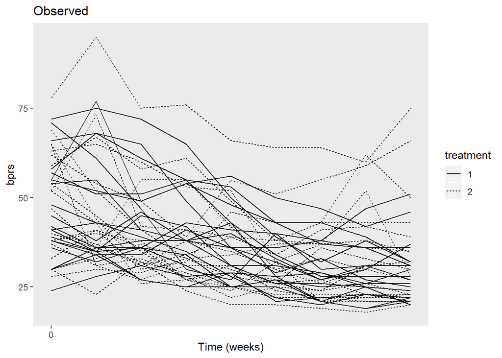

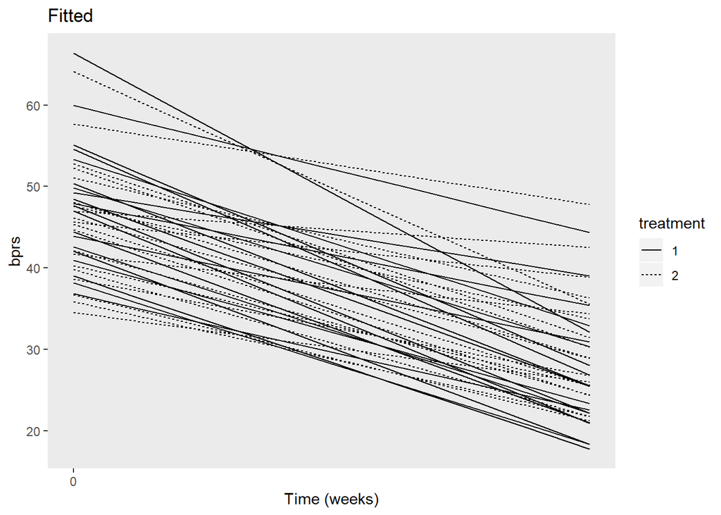

The above figure comparing fitted values of the interaction model and the observed values shows that the model fits the actual data quite well. However, the treatment does not appear to have predictive power about the rate of change of the bprs measure.

That’s it. Thanks for reading!